# Lateralidad de Edinburgh

## Procesamiento base

### Setup, chunk inicial

En general aquellas funciones y librerías que deben estar disponibles para el documento es recomendable colocarlas en el chunk **setup** el cual tiene características especiales como no mostrar resultados y ejecutarse automáticamente en cada **R notebook**. Esta práctica facilita la organización de librerías y depuración de errores. En lo personal me parece de gran utilidad el uso de archivos separados para funciones y segmentos grandes de código, dejando en el **notebook** el código de procesamiento mínimo.

```r
source("ILEFunctions.R")
```

### Autenticación con Google

Para hacer uso del archivo en **Google** el primer paso es autentificarse. Google se vale de el servicio *oauth* para idetificarnos sin usar un password. El siguiente comando abre una pagina de nuestro navegador donde se nos requiere permitir acceso a la sesión de R acceso a nuestros archivos.

```r
gs_auth()
```

> Este método genera credenciales locales. Tenemos que ser cuidadosos de no publicarlas en el caso de usar un sistema de control de versiones. Sin emabrgo estas se puede revocar en la pagina de Google, ademas de tener una caducidad.

### Descarga de información

Ya autenticados se necesita definir el *“objeto”* o archivo donde tenemos la información.

```r
gs.object <- gs_title("ILE [R en la Nube] (Respuestas)")
```

Con el objeto definido podemos leer la información del archivo en una tabla

```r
ile.data <- gs_read(ss = gs.object, ws = "Respuestas de formulario 1")
```

### Procesamiento de datos

Y sobre esta tabla podemos hacer las transformaciones y métodos enfocados a los datos. Que en este caso uso la librería `data.table`, sin embargo por default los datos se leen en formato **tibble** facilitando la implementación de pipes (`%>%`).

```r
setDT(ile.data)
ile.data[, c("fecha", "hora") := tstrsplit(`Marca temporal`, " ")]
ile.data[, `:=`(`Marca temporal` = NULL, fecha = as.IDate(fecha), hora = as.ITime(hora))]
```

En el caso específico de este formulario, podemos directamente cambiar el formato de los datos, en específico el nombre de las preguntas para que sean manejables las tablas.

```r
nombres.originales <- names(ile.data)
nombres.cortos <- c("id.participante", paste0("P", 1:12))
setnames(ile.data, nombres.originales[-14:-15], nombres.cortos)
ile.data <- melt(
  ile.data, id.vars = c("id.participante", "fecha", "hora"), value.name = "valor", variable.name = "pregunta"
)
```

Es aquí donde se puede visualizar la ventaja real de R. Mientras que El formulario de Google presenta gráficos definidos estáticos, al importar los datos es mucho mas sencillo tratarlos con base en la características propias del formulario. Aquí se puede obtener el coeficiente de lateralidad para cada usuario. Y por supuesto se pueden obtener la estadística descriptiva, pruebas de hipótesis o modelos más complejos.

```r
ile.data[, valor.ajustado := valor - 3]
ile.data[valor.ajustado == 0, valor.ajustado := 1]
ile.data <- ile.data[, .(
  izquierda = .SD[(valor == 3 & valor.ajustado == 1) | (valor != 3 & valor.ajustado < 0), sum(abs(valor.ajustado))],
  derecha = .SD[(valor == 3 & valor.ajustado == 1) | (valor != 3 & valor.ajustado > 0), sum(abs(valor.ajustado))]
), .(id.participante, fecha, hora)]
ile.data[, indice.lateralidad := ((derecha - izquierda) / (derecha + izquierda)) * 100]
```

### Resultado

Tenemos entonces la tabla resultante con el **Indice de lateralidad** calculado:

```r
ile.data
```

| id.participante | fecha | hora | izquierda | derecha | indice.lateralidad |
| --- | --- | --- | --- | --- | --- |
| R001 | 13-11-20 | 20:38:51 | 2 | 22 | 83.33333 |
| R002 | 14-11-20 | 10:06:38 | 2 | 13 | 73.33333 |
| R003 | 14-11-20 | 10:07:55 | 17 | 1 | -88.88889 |
| R004 | 14-11-20 | 10:08:15 | 11 | 11 | 0.00000 |
| R005 | 14-11-20 | 10:08:38 | 0 | 20 | 100.00000 |
| R006 | 14-11-20 | 10:09:48 | 0 | 24 | 100.00000 |
| R007 | 14-11-20 | 10:10:12 | 0 | 22 | 100.00000 |
| R008 | 14-11-20 | 10:10:31 | 0 | 20 | 100.00000 |
| R009 | 14-11-20 | 10:10:52 | 0 | 22 | 100.00000 |
| R010 | 14-11-20 | 10:11:19 | 2 | 18 | 80.00000 |

[output cut: 6 more lines]

Ademas de que podemos incluir representaciones gráficas de los resultados:

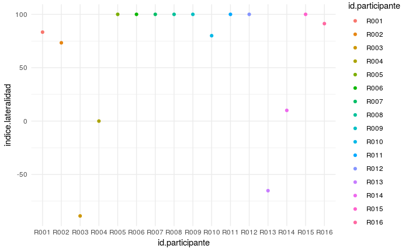

```r
ggplot(ile.data, aes(x = id.participante, y = indice.lateralidad, col = id.participante)) +
  geom_point() +
  theme_minimal()
```

```r
NA
```

## Procedimiento con Funciones

Otra recomendación consiste en pasar esta lógica programada a funciones, lo que permite tanto simplificar las llamadas en el documento, como un mejor uso de la memoria RAM, así como la introducción de practicas de depuración mas avanzadas.

```r
ile.data <- ImportarDatosILE(
  titulo.archivo = "ILE [R en la Nube] (Respuestas)",titulo.hoja = "Respuestas de formulario 1"
)
```

```
Downloading: 420 B
Downloading: 420 B
Downloading: 430 B
Downloading: 430 B
Downloading: 430 B
Downloading: 430 B
Downloading: 430 B
Downloading: 430 B
```

Incluso se facilita la lectura del código si se usan nombres descriptivos para cada función.

```r
ile.data <- CalculaIndiceLateralidad(ile.data)
ile.data
```

| id.participante | fecha | hora | izquierda | derecha | indice.lateralidad | predominancia |
| --- | --- | --- | --- | --- | --- | --- |
| R0001 | 13-11-20 | 20:38:51 | 2 | 22 | 83.33 | derecho |
| R0002 | 14-11-20 | 10:06:38 | 2 | 13 | 73.33 | derecho |
| R0003 | 14-11-20 | 10:07:55 | 17 | 1 | -88.89 | izquierdo |
| R0004 | 14-11-20 | 10:08:15 | 11 | 11 | 0.00 | derecho |
| R0005 | 14-11-20 | 10:08:38 | 0 | 20 | 100.00 | derecho |
| R0006 | 14-11-20 | 10:09:48 | 0 | 24 | 100.00 | derecho |
| R0007 | 14-11-20 | 10:10:12 | 0 | 22 | 100.00 | derecho |
| R0008 | 14-11-20 | 10:10:31 | 0 | 20 | 100.00 | derecho |
| R0009 | 14-11-20 | 10:10:52 | 0 | 22 | 100.00 | derecho |
| R0010 | 14-11-20 | 10:11:19 | 2 | 18 | 80.00 | derecho |

[output cut: 6 more lines]

Dejando el procesamiento mas puntual para el archivo como el filtrado o visualización de los datos.

```r
ile.data[ indice.lateralidad > 50]
```

| id.participante | fecha | hora | izquierda | derecha | indice.lateralidad | predominancia |
| --- | --- | --- | --- | --- | --- | --- |
| R0001 | 13-11-20 | 20:38:51 | 2 | 22 | 83.33 | derecho |
| R0002 | 14-11-20 | 10:06:38 | 2 | 13 | 73.33 | derecho |
| R0005 | 14-11-20 | 10:08:38 | 0 | 20 | 100.00 | derecho |
| R0006 | 14-11-20 | 10:09:48 | 0 | 24 | 100.00 | derecho |
| R0007 | 14-11-20 | 10:10:12 | 0 | 22 | 100.00 | derecho |
| R0008 | 14-11-20 | 10:10:31 | 0 | 20 | 100.00 | derecho |
| R0009 | 14-11-20 | 10:10:52 | 0 | 22 | 100.00 | derecho |
| R0010 | 14-11-20 | 10:11:19 | 2 | 18 | 80.00 | derecho |
| R0011 | 14-11-20 | 10:12:02 | 0 | 22 | 100.00 | derecho |
| R0012 | 14-11-20 | 10:12:20 | 0 | 22 | 100.00 | derecho |

[output cut: 2 more lines]